# 10 — Other networks: architectures and applications

Machine Learning (MPA-MLR)

Roman Jakubíček · Jiří Chmelík

Department of Biomedical Engineering · FEEC, Brno University of Technology

2026

## Outline

1 · Regression and classification

One encoder, a small head on top; which output, which loss.

2 · Image-to-image

Encoder–decoder: denoising, modality transfer, paired and unpaired data.

3 · Segmentation

A class in every pixel; overlap losses, U-Net and nnU-Net.

4 · Object detection

Boxes and classes; IoU and NMS, Faster R-CNN, YOLO.

5 · Practical tricks

Transfer learning, freezing, augmentation, learning with few labels.

6 · Sequences

1D convolution, recurrent networks and the LSTM — the bridge to the next lecture.

## 1 · Regression and classification

> The simplest architecture there is: an encoder squeezes the image into a small, deep map, and a small head turns it into the answer.

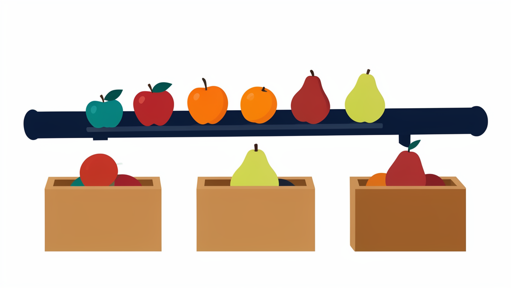

Illustration generated by AI (FLUX.2)

## One backbone, two heads

[figure not shown]

Backbone

- **Architecture:** encoder $\Rightarrow$ fully connected (**FC**) layer
- **Encoder:** any CNN backbone — here **VGG-16**
- **$224 \times 224 \to 7 \times 7$** after five poolings

Two heads

|  | regression | classification |
| --- | --- | --- |
| output | $\hat y_1 \dots \hat y_m$ | $\hat y_1 \dots \hat y_C$ |
| activation | none | **softmax** |
| loss | $L_1$ / $L_2$ | weighted cross-entropy |

Only the **activation** and the **loss** differ — the backbone is literally the same network.

Backbone drawn after Simonyan & Zisserman, *Very Deep Convolutional Networks for Large-Scale Image Recognition*, ICLR 2015.

## Regression — output layer and loss

Last layer

- fully connected, or equivalently a $1 \times 1$ convolution,
- **no activation** — any real value (ReLU or softmax only in special cases),
- one neuron per regressed value.

Predict relative values

A position as $x / W \in [0, 1]$, not in pixels; detection does the same with offsets relative to an anchor.

**Loss:** $L_1$ or $L_2$, summed over the $m$ outputs

$$\mathcal L = \lVert \hat{\mathbf y} - \mathbf y \rVert_1 = \sum_{j=1}^{m} |\hat y_j - y_j|,
\qquad
\mathcal L = \lVert \hat{\mathbf y} - \mathbf y \rVert_2^2 = \sum_{j=1}^{m} (\hat y_j - y_j)^2$$

A regression head is one matrix multiplication. Everything hard happens in the encoder before it.

## How large is that encoder, really?

| VGG-16 | tensor shape |
| --- | --- |
| input | 224 × 224 × 3 |
| block 1 (64 ch.) + pool | 112 × 112 × 64 |
| block 2 (128 ch.) + pool | 56 × 56 × 128 |
| block 3 (256 ch.) + pool | 28 × 28 × 256 |
| block 4 (512 ch.) + pool | 14 × 14 × 512 |
| block 5 (512 ch.) + pool | 7 × 7 × 512 |
| flatten | **25 088** |

[figure not shown]

After flattening, $7 \cdot 7 \cdot 512 = 25\,088$ values enter FC1:

$$25\,088 \cdot 4096 + 4096 = 102\,764\,544$$

parameters in **one** layer — **74 %** of the whole network.

**138.4 M** parameters in total, but **99 %** of the arithmetic happens in the convolutions.

Computed in [`code/parameter_counts.py`](https://github.com/tomasvicar/MLR-public/blob/master/lectures/L10/code/parameter_counts.py).

## Softmax and cross-entropy on real numbers

[figure not shown]

One-hot encoding

The output vector holds the probability of each class; its length equals the number of classes $C$. The predicted class is the one with the highest probability.

Integer encoding

The output may instead be a single integer — a class label. It is a reasonable choice only for **ordinal** variables (grade 1–4), where the order of the labels carries meaning.

## Encoders — accuracy, parameters, operations

[figure not shown]

**Parameters ≠ operations.**

- VGG-16 vs ResNet-50: **5.4×** the parameters, only **3.8×** the operations.
- MobileNet-v2 vs ResNet-50: **7.3×** fewer parameters, **13.6×** fewer operations.
- **Newer** (orange): the same ResNet-50 reaches **80.9 %** with a better training recipe.

**Parameters** decide the memory for the weights and the optimizer state, **operations** the time of one forward pass.

Accuracies after Bianco, Cadène, Celona, Napoletano, *Benchmark Analysis of Representative Deep Neural Network Architectures*, IEEE Access 6 (2018); highlighted models computed in [`code/parameter_counts.py`](https://github.com/tomasvicar/MLR-public/blob/master/lectures/L10/code/parameter_counts.py); orange points from the [torchvision model table](https://docs.pytorch.org/vision/main/models.html).

## 2 · Image-to-image

> Keep the output an image and the fully connected head disappears — what is left is an encoder with a decoder glued behind it.

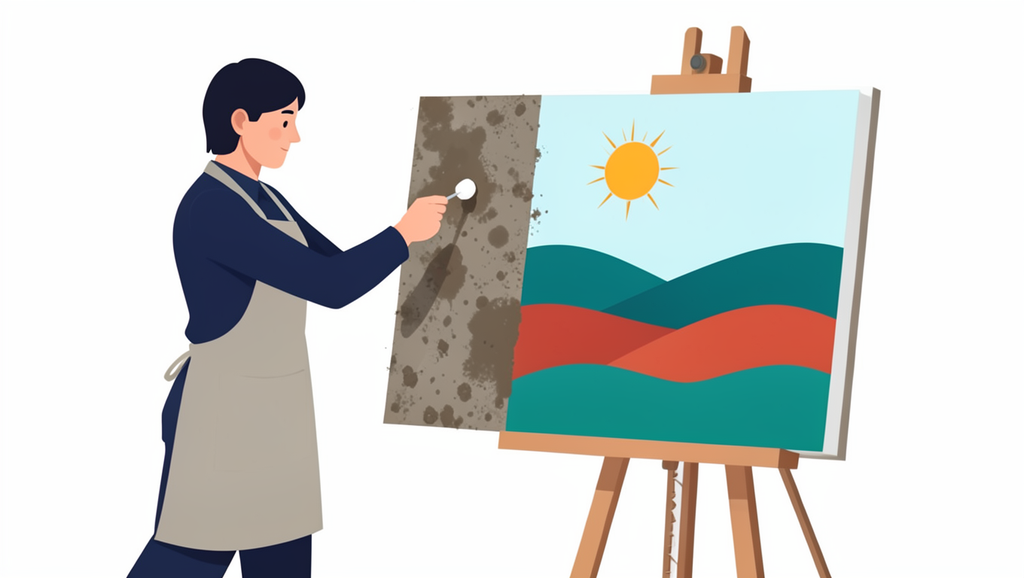

Illustration generated by AI (FLUX.2)

## Image regression

Architecture

encoder–decoder

Input → output

image → image

Loss

$L_1$ or $L_2$, per pixel

Last layer

convolution, **linear** activation

[figure not shown]

- We need **paired data** — a reference image for every input image. That is often the hard part.
- If we do not have them, we can create them **synthetically** (simulate the degradation) or acquire them (scan the same sample twice).
- Some methods need no pairs at all — **unpaired** training, two slides on (CycleGAN).

## Sizes through an encoder–decoder

| layer | output shape | parameters |
| --- | --- | --- |
| input | 256 × 256 × 1 | — |
| conv 3×3 → 32 | 256 × 256 × 32 | 320 |
| max pool 2×2 | 128 × 128 × 32 | — |
| conv 3×3 → 64 | 128 × 128 × 64 | 18 496 |
| max pool 2×2 | 64 × 64 × 64 | — |
| conv 3×3 → 128 | 64 × 64 × 128 | 73 856 |
| max pool 2×2 | 32 × 32 × 128 | — |
| conv 3×3 → 256 | 32 × 32 × 256 | 295 168 |
| up-conv 2×2 → 128 | 64 × 64 × 128 | 131 200 |
| conv 3×3 → 128 | 64 × 64 × 128 | 147 584 |
| up-conv 2×2 → 64 | 128 × 128 × 64 | 32 832 |
| conv 3×3 → 64 | 128 × 128 × 64 | 36 928 |
| up-conv 2×2 → 32 | 256 × 256 × 32 | 8 224 |
| conv 3×3 → 32 | 256 × 256 × 32 | 9 248 |
| conv 1×1 → 1 | 256 × 256 × 1 | 33 |
| **total** |  | **753 889** |

Convolution (eighth lecture):

$$H_{l+1} = \frac{H_l - F + 2P}{S} + 1$$

Transposed convolution — the $(N-1)S + F$ of the ninth lecture, **size only**:

$$H_{l+1} = (H_l - 1)\,S + F$$

$2 \times 2$, stride 2: $(128 - 1) \cdot 2 + 2 = 256$ — three of them undo three poolings.

**753 889** parameters — 180× fewer than VGG-16, no FC layer.

## Image regression — where it is used

**Applications**

- image **segmentation**,
- **noise reduction**,
- reconstruction from a **sinogram**,
- transformation into a new image — style, modality, season.

The example on the right is **unpaired** — there is no photograph of the same horse as a zebra. CycleGAN learns from two unpaired sets by requiring that the round trip returns the original image.

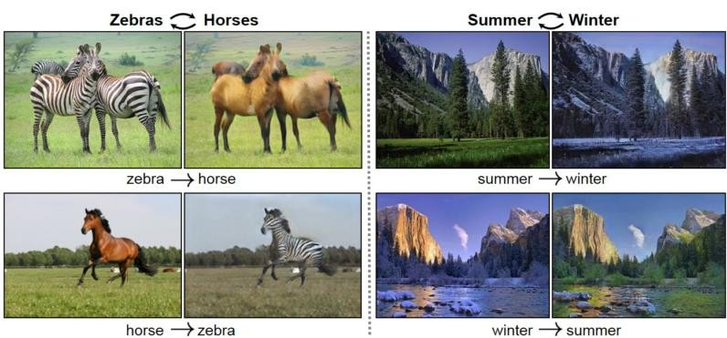

Figure from Zhu, Park, Isola, Efros (CycleGAN), ICCV 2017.

## Paired data — two examples

InputNetwork outputReference

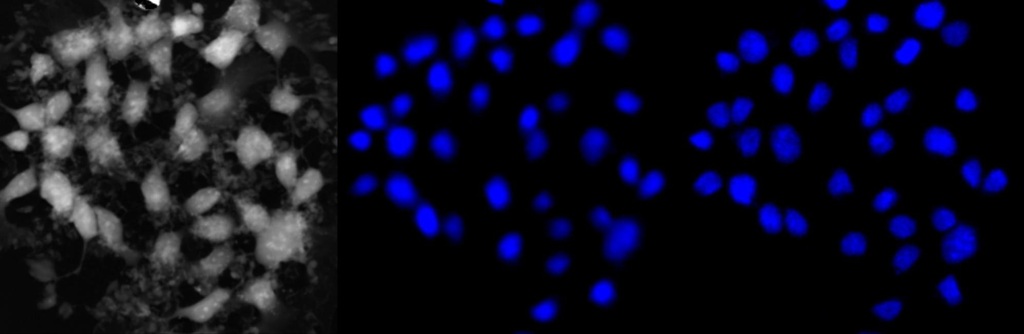

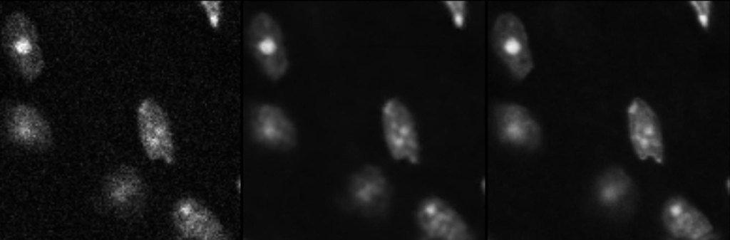

Top: transmitted light → fluorescence (no staining); bottom: short exposure → long exposure. Video: [content-aware image restoration (CARE)](https://www.youtube.com/watch?time_continue=24&v=ooeHl_qmqzI&feature=emb_logo)

## Noise reduction — learn the noise, not the image

[figure not shown]

The network is trained to output the **residual** $R = X - Y$, not the clean image. At inference the reference is gone, the network supplies the middle panel itself, and

$$\hat Y = X - f_{\boldsymbol\theta}(X).$$

The residual has **no anatomy**, and its spread is a third of the image’s → easier to learn; an output of 0 passes the input through unchanged.

Simulated computed tomography (CT): Shepp–Logan phantom, own Radon transform and filtered back-projection (FBP) — input from **45** projections, reference from **360**. The middle panel is the **training target**, not the output of a trained model.

## 3 · Segmentation

> Segmentation is image regression with a class label in every pixel — and it is where the architecture stops being a plain funnel.

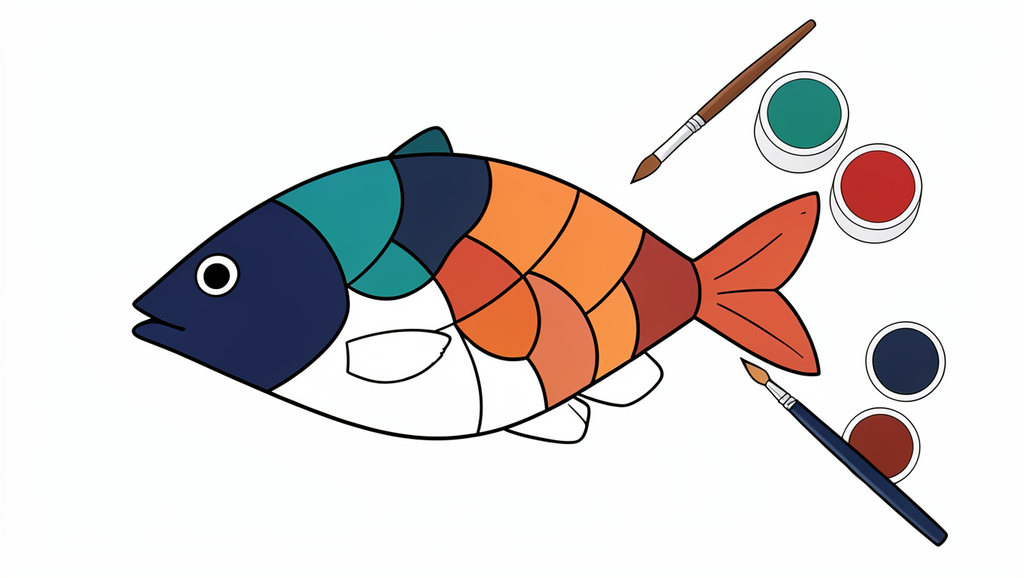

Illustration generated by AI (FLUX.2)

## Image segmentation

A special case of the image-to-image transformation — the output is a **class label for each pixel**.

Architecture

encoder–decoder

Input

image

Output

a 2D probability map for each class: $W \times H \times C$; **argmax** per pixel

Last layer

convolution with depth $C$ (the number of classes), **softmax across the channels** in every pixel

[figure not shown]

Encoder–decoder drawn after Badrinarayanan, Kendall, Cipolla, *SegNet*, IEEE TPAMI 39(12), 2017.

## Segmentation losses

**Weighted cross-entropy** (seventh lecture), summed over the $n$ pixels

$$\mathcal L = -\sum_{i=1}^{n} \sum_{c=1}^{C} \omega_c\, y_{i,c} \log \hat y_{i,c}$$

Per pixel → small classes vanish → **weights** $\omega_c$.

**Tversky index** (maximized; loss $1 - \mathrm{TI}$)

$$\mathrm{TI} = \frac{\mathrm{TP}}{\mathrm{TP} + \alpha\,\mathrm{FP} + \beta\,\mathrm{FN}}$$

$\alpha = \beta = 0.5$ → **Dice** ($F_1$), $\alpha = \beta = 1$ → **IoU**; larger $\beta$ punishes FN.

The seventh lecture’s $T$ *is* the loss $1 - \mathrm{TI}$.

[figure not shown]

Classical baseline to compare against: [`code/classical_segmentation.py`](https://github.com/tomasvicar/MLR-public/blob/master/lectures/L10/code/classical_segmentation.py) — Otsu + morphology reaches Dice 0.98 on a clean image, but only 0.58 under uneven illumination.

## Dice, IoU and Tversky — too small versus too large

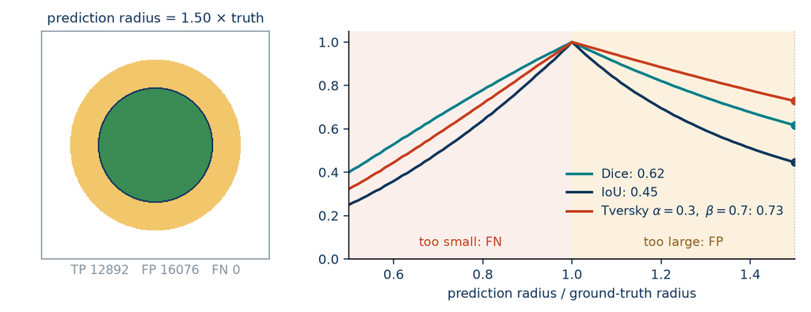

- All three reach **1 only for a perfect match**; IoU is never above Dice.
- Radius **25 % too small**: Dice 0.72, Tversky 0.65 — radius **25 % too large**: Dice 0.78, Tversky 0.86.
- With $\beta > \alpha$ the Tversky index **punishes the missed pixels (FN)** more than the false alarms (FP).

## Playground: move the prediction, watch the scores

[interactive chart not shown]

prediction radius / true radius =

prediction shifted right by × true radius

Tversky **α** (weight of FP) =

Tversky **β** (weight of FN) =

## U-Net (2015)

- Developed for **biomedical image segmentation** — and still the default choice.
- Long **skip connections** by **concatenation** (not addition).

The bottleneck tells the decoder **what**, the long skips tell it **where**.

The bottleneck

Two $3 \times 3$ convolutions, $512 \to 1024 \to 1024$, each followed by ReLU — no batch normalization in 2015.

Pre-training

No ImageNet-style universal U-Net; pre-trained models exist per task (TotalSegmentator) and as promptable foundation models (SAM, MedSAM); a pre-trained **VGG or ResNet encoder** can always go into the contracting path.

Ronneberger, Fischer, Brox, *U-Net: Convolutional Networks for Biomedical Image Segmentation*, MICCAI 2015 (arXiv:1505.04597).

## U-Net — the shapes come out of the arithmetic

[figure not shown]

Convolutions are **valid** (no padding): every $3 \times 3$ removes 2 pixels along each axis (one per side), every pooling halves, every $2 \times 2$ up-conv doubles: $(28 - 1) \cdot 2 + 2 = 56$. The output $388 \times 388 \times 2$ is **smaller than the input** — hence the **overlap-tile** strategy.

## Playground: do the U-Net sizes meet?

[interactive chart not shown]

input size

poolings valid 3×3 (paper) padding 1

presets:

## U-Net — where the 31 million parameters sit

[figure not shown]

Two convolutions in the bottleneck:

$$3^2 \cdot 512 \cdot 1024 + 3^2 \cdot 1024 \cdot 1024 \approx 14.2\ \text{M}$$

i.e. **46 %** of all 31.0 M parameters — on the smallest maps ($32^2 \to 30^2 \to 28^2$).

The first two convolutions, at full resolution ($572 \to 570 \to 568$), hold only **37 568** parameters — yet cost more arithmetic than the whole bottleneck.

Computed by [`code/parameter_counts.py`](https://github.com/tomasvicar/MLR-public/blob/master/lectures/L10/code/parameter_counts.py).

## nnU-Net — configure the training, not the architecture

[figure not shown]

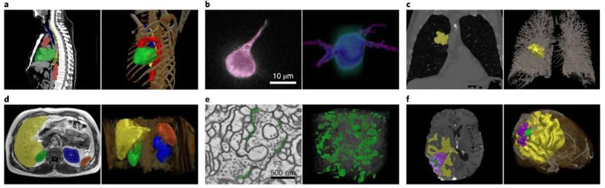

Isensee et al., *nnU-Net: a self-configuring method for deep learning-based biomedical image segmentation*, Nature Methods 18 (2021) 203–211 — https://www.nature.com/articles/s41592-020-01008-z

## TotalSegmentator — 100+ structures out of the box

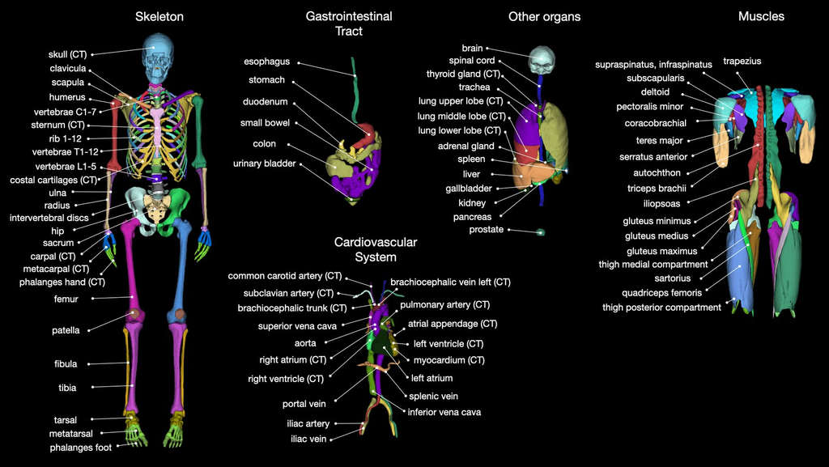

Wasserthal et al., *TotalSegmentator*, Radiology: Artificial Intelligence 5(5), 2023 — https://pubs.rsna.org/doi/10.1148/ryai.230024

## 4 · Object detection

> Not every pixel needs a label. Sometimes a box and a name are enough — but the network has to decide *how many* boxes there are.

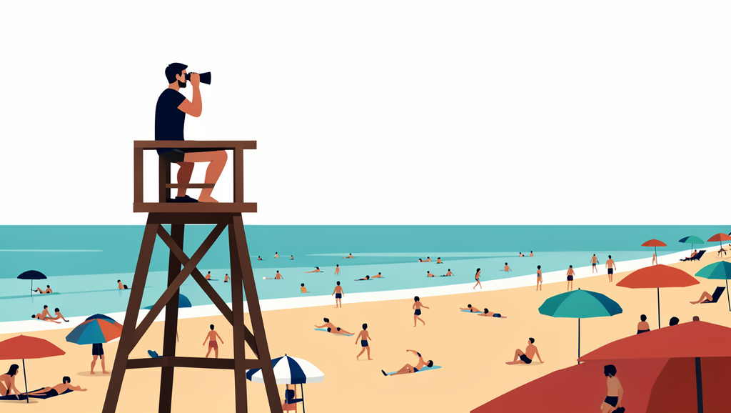

Illustration generated by AI (FLUX.2)

## Object detection

Output

**boxes** + a **class** for each object

Two tasks

**localization** + **classification** — sequentially, in parallel or in one step

Objects

cars, people, faces … lesions, organs, cells

[figure not shown]

## Box IoU and NMS by hand

[figure not shown]

$$\mathrm{IoU} = \frac{|A \cap B|}{|A \cup B|} = \frac{12}{24 + 30 - 12} = 0.29$$

**NMS** (non-maximum suppression): sort by score, keep the best, remove every box with IoU > 0.5 to it, repeat. 0.90 kept → 0.80 removed (IoU 0.68), 0.70 stays (0.33), 0.60 stays (0.16) → 0.70 kept → 0.60 removed (0.52).

## The most common detectors

- **R-CNN** family (region-based CNN) — Fast, Faster, Cascade R-CNN
- **SSD** — single shot detector
- **YOLO** — *you only look once*; v1 (2016) … YOLO26 (2026), from different groups
- **RetinaNet** — focal loss for the class imbalance (2017)
- and many more…

Two-stage was historically more accurate; since focal loss, **one-stage** detectors match it and are much faster — today’s real-time detectors are one-stage (the last slide of this block).

[figure not shown]

## Faster R-CNN

R-CNN $\Rightarrow$ Fast R-CNN $\Rightarrow$ Faster R-CNN — the third version.

**Two modules** sharing one convolutional backbone:

- **region proposal network (RPN)** — takes the feature map of an image **of any size** and outputs rectangular proposals, each with an **objectness score**,
- **Fast R-CNN detector** — region of interest (**RoI**) pooling + FC head: the class of every proposal and a refined box.

**RoI pooling** → a fixed $7 \times 7$ grid (next slide).

[figure not shown]

Drawn after Ren, He, Girshick, Sun, *Faster R-CNN: Towards Real-Time Object Detection with Region Proposal Networks*, NIPS 2015. The feature maps in the figure are real convolution responses (oriented Gabor filters).

## RoI pooling — any proposal, the same 7 × 7

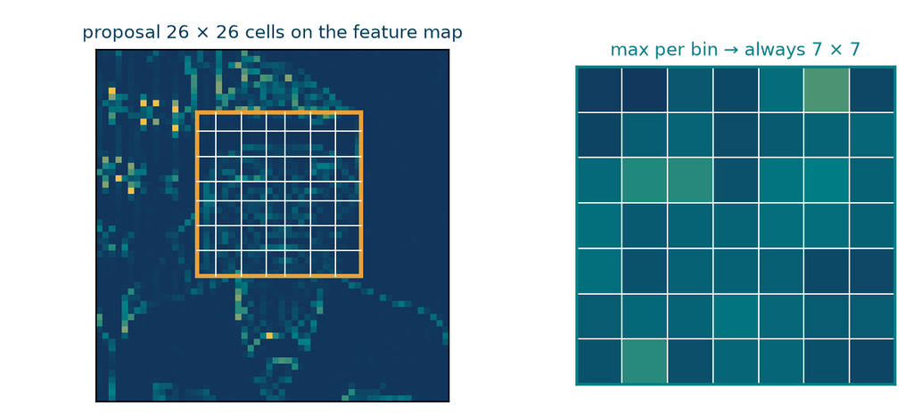

- The proposal is split into a **7 × 7 grid of bins**, whatever its size or aspect ratio.
- Each bin is **max-pooled** → a fixed-size input for the fully connected head.
- The feature map is computed **once**; every proposal only cuts out its own part of it.

## How many proposals is “a set of proposals”?

[figure not shown]

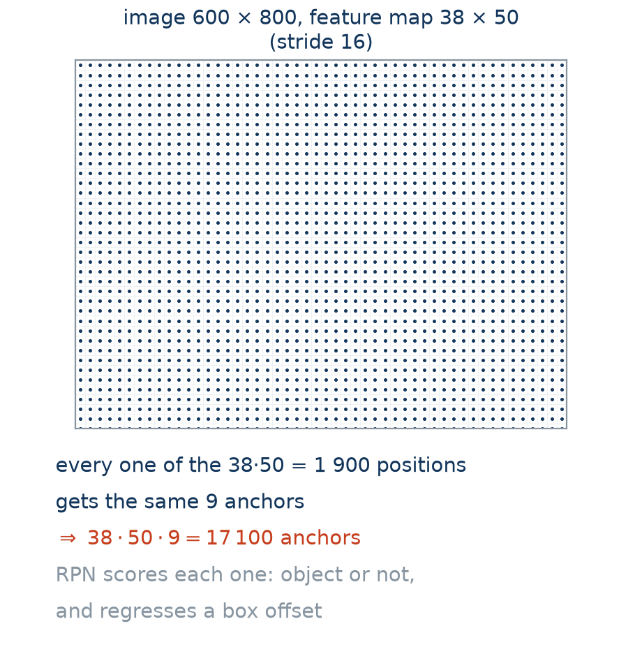

**Anchors** = reference boxes, 3 scales ($128^2, 256^2, 512^2$) × 3 aspect ratios at every position; the RPN regresses offsets relative to them. NMS + top-N keep ~2 000 proposals.

## One-stage: YOLO

[figure not shown]

- **One pass, no proposals:** an $S \times S$ grid, each cell predicts $B$ boxes ($x, y, w, h$, confidence) + $C$ class probabilities → $S \times S \times (5B + C)$.
- **YOLOv1:** $S = 7$, $B = 2$, $C = 20$ → $7 \times 7 \times (2 \cdot 5 + 20) = 7 \times 7 \times 30$.
- **Today:** anchor-free heads (since YOLOv8, 2023); YOLO26 (2026) adds an **NMS-free** head; **DETR** (2020, a transformer) predicts a set of boxes directly — no anchors, no NMS.

Redmon et al., *You Only Look Once*, CVPR 2016 · Carion et al., *DETR*, ECCV 2020 · [Ultralytics YOLO26 docs](https://docs.ultralytics.com/models/yolo26/)

## 5 · Practical tricks

> Almost nobody trains from scratch. This block is about starting from somebody else’s weights — and about making your own data go further.

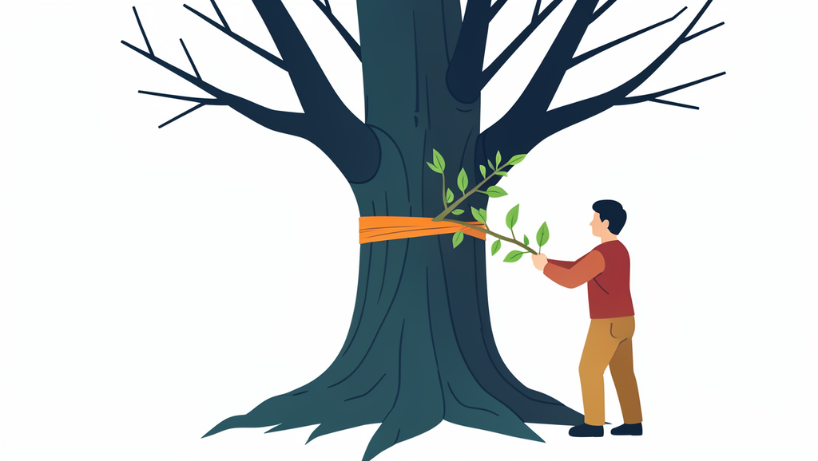

Illustration generated by AI (FLUX.2)

## Transfer learning — why it works at all

- The first layers learn filters that **look like edge detectors** — first and second derivatives, Gabor and Haar-like masks.
- Later layers **combine** them into complex, task-specific features.
- Transfer learning = take a **pre-trained model** (its weights) and **fine-tune** it on our own dataset.

The first layer of a network trained on cats is useful for a network that segments livers, because edges look the same in both.

[figure not shown]

Left: filters learned by independent component analysis (ICA) from 6 000 patches of a photograph — no labels, no network. Right: the classical operators listed above.

## Pre-trained networks

- **ResNet, ConvNeXt, ViT, …** pre-trained on **ImageNet** (ILSVRC: 1000 classes, 1.28 M images); today from torchvision, timm or the Hugging Face Hub.
- Their weights = **initial values** for fine-tuning.
- Workflow: load → **replace the last layer** → fine-tune → evaluate → deploy.

Pros

- training takes much less compute time,
- a better starting point in a cost function full of local minima,
- **reduces the risk of overfitting** on a small dataset.

Cons

- the **re-used part** must keep the architecture it was pre-trained with,
- the best model for us may be **non-standard**,
- ImageNet is natural photographs — the further our data are from it (CT, ultrasound, spectra), the less it helps.

Only the re-used part is fixed. A pre-trained VGG can serve as the encoder of a U-Net, and the decoder can be anything.

## Freeze approach

- **early layers** = general features (edges, gradients); **late layers** = specific (eyes, wheels)
- **freeze** the first $n$ layers, **fine-tune** the rest
- frozen = no update in backpropagation

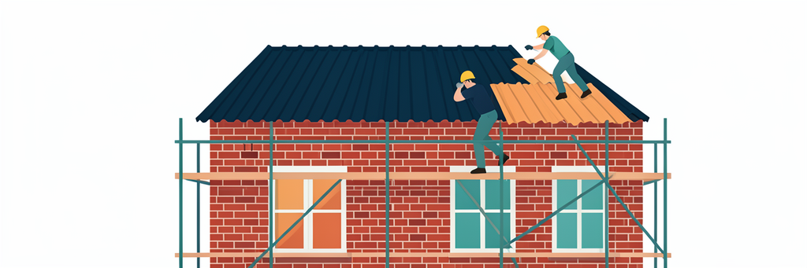

Illustration generated by AI (FLUX.2)

[figure not shown]

## Freezing — how much do we actually save?

[figure not shown]

AlexNet with a 10-class head has **56.9 M** parameters, but only **2.33 M** of them are in the five convolutional layers.

Freeze C1–C5

the usual meaning of “freeze the convolutions” $\rightarrow$ still **95.9 %** of the parameters are trained

Freeze C1–FC6

$\rightarrow$ **29.6 %** are trained

Freeze C1–FC7

train the new last layer only $\rightarrow$ **0.1 %**

All three get called “freezing” — **say which one you mean.** The smaller the dataset, the further the frozen part should reach.

## Data augmentation

**Synthetic, realistic variants** of the training images → a more robust network.

Types

- geometric transformations (flip, rotation, scaling, crop, …),
- intensity / contrast modification (point-wise operations, colour),
- added noise,
- blurring / sharpening,
- data mixing (mixup, CutMix),
- data masking / erasing,
- generated images (GAN, diffusion models).

The rule that decides everything

Apply only transformations whose result could have come out of the real acquisition — and which do **not** change the label.

- A horizontal flip is fine for cats. It is **not** fine for a chest X-ray, where it turns situs solitus into situs inversus.
- A rotation is fine for microscopy (there is no “up”). It is questionable for handwritten digits, where a 6 turned upside down becomes a 9.
- Whatever transformation the input gets, the **mask must get the same one** in segmentation.

## Data augmentation — enlarge your dataset

[figure not shown]

Nine transformations of one photograph. Each of them keeps the label — it is still the same person — while the pixel values change a lot: the geometric ones move almost every pixel, the intensity ones keep the geometry and change the statistics.

All nine transformations are really computed, with a table of how much each one changes the mean, the spread and the pixel values: [`code/augmentation.py`](https://github.com/tomasvicar/MLR-public/blob/master/lectures/L10/code/augmentation.py).

## Data augmentation — offline or online?

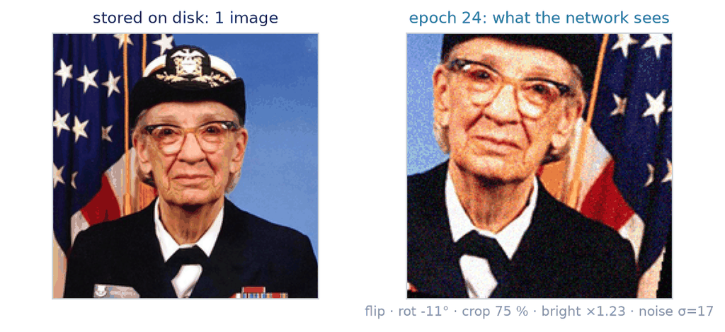

**Offline** — the variants are generated once, before training. Suitable for small datasets; costs disk space, and the set of variants is fixed.

**Online** — on the fly, with parameters drawn at random for every mini-batch. The network **almost never sees exactly the same image twice**; one stored image becomes a different training sample in every epoch.

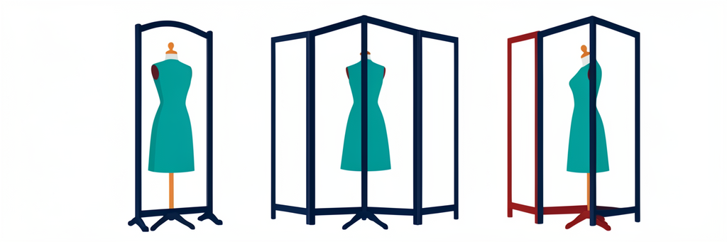

Illustration generated by AI (FLUX.2)

## Self-supervised learning (SSL)

- Learns from **unlabelled** data by creating **pseudo-labels from the data itself**.
- **Pretext tasks** — image inpainting, rotation prediction, contrastive learning, masked image modelling — guide the representation learning.
- Produces general feature **embeddings**, useful for downstream tasks with few labels.

The label is free because the data already contain it — we only have to hide part of it and ask the network to guess.

[figure not shown]

[figure not shown]

Illustration generated by AI (FLUX.2)

## Contrastive loss by hand (InfoNCE)

[figure not shown]

Anchor $\mathbf e_a$, positive $\mathbf e_+$ (another view of the same image), negatives $\mathbf e_1, \mathbf e_2$ (other images), temperature $\tau$:

$$\mathcal L = -\log \frac{\exp\!\big(\cos(\mathbf e_a, \mathbf e_+)/\tau\big)}{\sum_{k \in \{+, 1, 2\}} \exp\!\big(\cos(\mathbf e_a, \mathbf e_k)/\tau\big)}$$

By hand, $\tau = 0.5$

- cosines $0.8,\ 0,\ -0.6$ → divided by $\tau$: $1.6,\ 0,\ -1.2$,
- $\exp$: $4.95,\ 1,\ 0.30$ → softmax of the positive $4.95 / 6.25 = 0.79$,
- $\mathcal L = -\log 0.79 = 0.23$.

## Weakly supervised learning (WSL)

Learns from **imperfect or limited** supervision:

- **noisy labels** — wrong or sloppy (different readers, extraction from reports) → **robust losses**,
- **incomplete labels** — only part of the data, or of every image, annotated → **partial / masked losses**,
- **inexact labels** — coarser than the task (image labels for a pixel task, boxes instead of masks) → **multiple instance learning**, class activation maps.

[figure not shown]

**MIL by hand:** patches $\hat y_j = (0.10, 0.05, 0.70, 0.20, 0.15)$ → image $\hat y = \max_j \hat y_j = 0.70$; label $y = 1$ → binary cross-entropy $\mathcal L = -\log 0.70 = 0.36$.

## 6 · Sequences

> The input stops being a fixed-size image and becomes a sequence — so the network needs a memory.

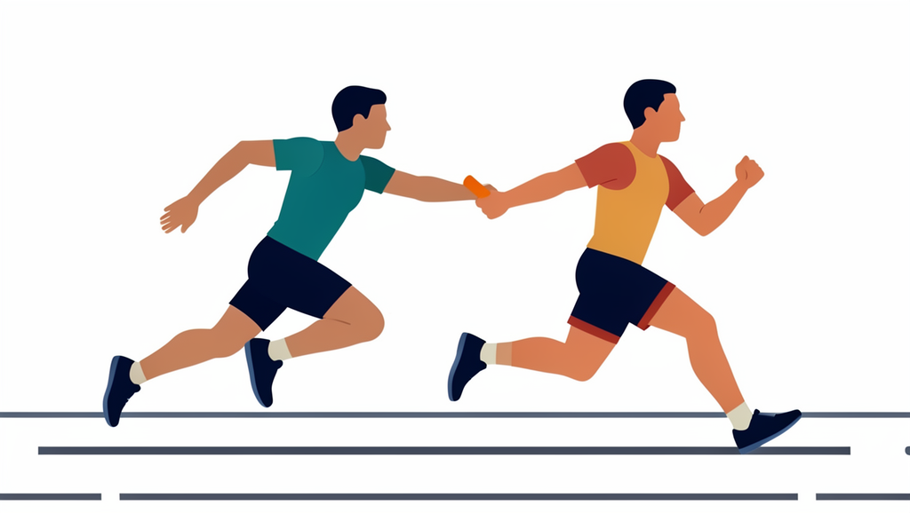

Illustration generated by AI (FLUX.2)

## Signals — the same table in 1D

[figure not shown]

| head | output | loss |
| --- | --- | --- |
| rhythm classification | $C$ probabilities | cross-entropy |
| QRS detection | $n$ probabilities | binary cross-entropy |
| denoising | $n$ samples | $L_1$ / $L_2$ |

Output length by hand

$n_\text{out} = \frac{n - F + 2P}{S} + 1$, for $n = 1000$, $F = 7$: $P = 0$ → 994; $P = 3$ → 1000; then max-pool $F = S = 2$ → 500.

## Recurrent networks — the recurrent cell

A recurrent neural network (**RNN**): the hidden state $\mathbf h$ = the network’s **own output** from the previous time step.

$$\mathbf h_t = \tanh\!\left(W_h \mathbf h_{t-1} + W_x \mathbf x_t + \mathbf b_h\right)$$
$$\hat{\mathbf y}_t = g\!\left(W_y \mathbf h_t + \mathbf b_y\right)$$

$g$: softmax or identity; the **same** $W_h$, $W_x$, $W_y$ at every step → **11 numbers** below, for any length.

**One step by hand** — $d_x = 1$, $d_h = 2$, $d_y = 1$, $g$ = identity, biases zero, $W_h = \left(\begin{smallmatrix} 0.5 & -1 \\ 1 & 0.5 \end{smallmatrix}\right)$, $W_x = (1, -1)^\top$, $W_y = (1, 1)$. For $\mathbf h_{t-1} = (1, 0)^\top$ and $x_t = 2$: $\mathbf z_t = (0.5 + 2,\ 1 - 2)^\top = (2.5, -1)^\top$, $\mathbf h_t = (\tanh 2.5,\ \tanh(-1))^\top = (0.987, -0.762)^\top$, $\hat y_t = 0.987 - 0.762 = 0.225$.

[figure not shown]

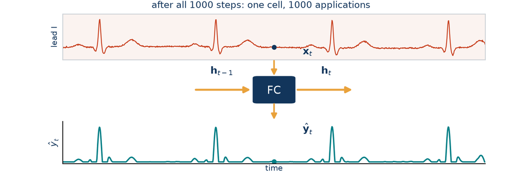

## Backpropagation through time

**Backpropagation through time** unrolls the loop and applies the chain rule along it:

$$\frac{\partial \mathbf h_n}{\partial \mathbf h_0} = J_n J_{n-1} \cdots J_1,
\qquad
J_t = \operatorname{diag}\!\big(\tanh'(\mathbf z_t)\big)\, W_h$$

with $\mathbf z_t = W_h \mathbf h_{t-1} + W_x \mathbf x_t + \mathbf b_h$. The same $W_h$ multiplies the gradient **once per step**. For a scalar state
$$\Big|\prod_{t=1}^{n} w\,(1 - h_t^2)\Big| \le |w|^n, \qquad
0.9^{50} = 0.005, \qquad 1.1^{50} = 117$$
— vanishing for $|w| < 1$, exploding for $|w| > 1$ in the linear regime. Any $|h_t|$ clearly above 0 pushes the factors below $|w|$ — here even $w = 1.1$ ends up vanishing.

[figure not shown]

## Playground: the gradient through time

[interactive chart not shown]

Scalar RNN h<sub>t</sub> = tanh(w·h<sub>t−1</sub> + x<sub>t</sub>), h<sub>0</sub> = 0, the 50 inputs of the figure on the previous slide.

recurrent weight **w** =

input amplitude (std of x) =

dashed |w|<sup>n</sup>

## LSTM — gates and one step by hand

$$\begin{aligned}
\mathbf f_t &= \sigma\!\left(W_f [\mathbf h_{t-1}, \mathbf x_t] + \mathbf b_f\right) && \text{forget}\\
\mathbf i_t &= \sigma\!\left(W_i [\mathbf h_{t-1}, \mathbf x_t] + \mathbf b_i\right) && \text{input}\\
\tilde{\mathbf c}_t &= \tanh\!\left(W_c [\mathbf h_{t-1}, \mathbf x_t] + \mathbf b_c\right) && \text{candidate}\\
\mathbf c_t &= \mathbf f_t \odot \mathbf c_{t-1} + \mathbf i_t \odot \tilde{\mathbf c}_t && \text{cell state}\\
\mathbf o_t &= \sigma\!\left(W_o [\mathbf h_{t-1}, \mathbf x_t] + \mathbf b_o\right) && \text{output}\\
\mathbf h_t &= \mathbf o_t \odot \tanh(\mathbf c_t) && \text{hidden state}
\end{aligned}$$

[figure not shown]

Along $\mathbf c_{t-1} \to \mathbf c_t$ the gradient is multiplied only by $\mathbf f_t$ — the vanishing is **greatly mitigated**, not removed.

**One step by hand** — scalar state, $[h_{t-1}, x_t] = [0.5,\ 1]$, $c_{t-1} = 2$, biases zero, $W_f = (1, -0.5)$, $W_i = (2, 1)$, $W_c = (0, 1)$, $W_o = (-2, 0)$. Pre-activations $0,\ 2,\ 1,\ -1$ → $f_t = 0.5$, $i_t = 0.881$, $\tilde c_t = 0.762$, $o_t = 0.269$; $c_t = 0.5 \cdot 2 + 0.881 \cdot 0.762 = 1.671$, $h_t = 0.269 \cdot \tanh 1.671 = 0.251$.

## Recurrent networks today

Pros

- sequences of **any length**; the model does **not grow** with the length,
- the state carries information over time; the LSTM **learns what to forget**,
- cheap per step — streaming and low-power signal processing.

Cons

- vanishing / exploding gradients — only mitigated by the LSTM and the gated recurrent unit (**GRU**),
- **4×** the parameters for an LSTM,
- **cannot be parallelized over time** — step $t$ needs step $t - 1$.

[figure not shown]

For $d_x = 3$, $d_h = 64$, $d_y = 1$: RNN $d_h(d_h + d_x) + d_h + d_y d_h + d_y = 4\,417$; LSTM $4[d_h(d_h + d_x) + d_h] + d_y d_h + d_y = 17\,473$; GRU $13\,121$.

In language the recurrence has been replaced by the **transformer** — the next lecture — which drops it and can therefore be parallelized.

## 7 · Recap

> One shared idea behind all of it: an encoder that compresses, and a head that answers the question you asked.

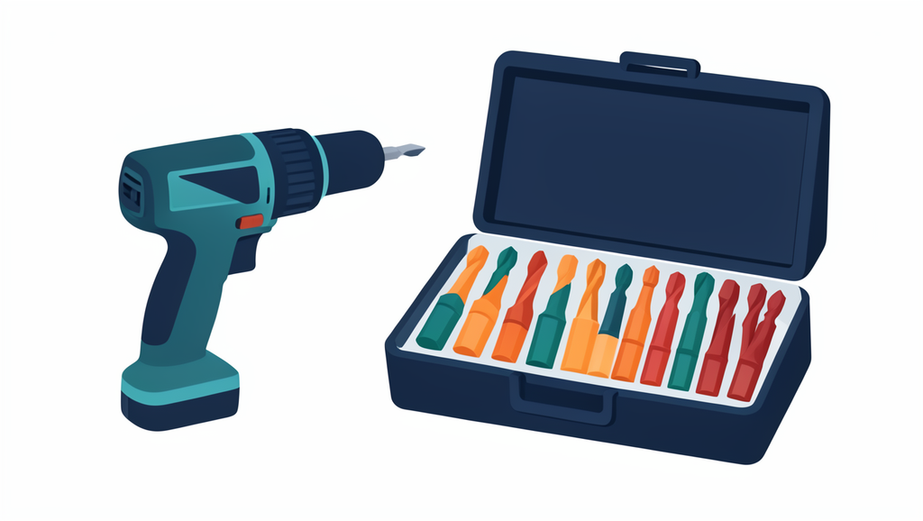

Illustration generated by AI (FLUX.2)

## Summary — one encoder, many heads

| task | output | last layer | loss |
| --- | --- | --- | --- |
| regression | $m$ numbers | FC, linear | $L_1$, $L_2$ |
| classification | $C$ probabilities | FC, softmax | weighted cross-entropy |
| image-to-image | image | conv, linear | $L_1$, $L_2$ |
| segmentation | $W \times H \times C$ | conv, softmax across channels | cross-entropy + Dice |
| detection | boxes + scores | box + class head (Faster R-CNN, YOLO) | cross-entropy + box regression |
| signals | as above, in 1D | `Conv1d` + the same heads | as above |
| sequences | per-step output | RNN / LSTM cell | task-dependent |

Three numbers worth remembering

- VGG-16: **138 M** parameters, 74 % of them in one fully connected layer.
- U-Net: **31 M** parameters, 46 % of them in the bottleneck.
- LSTM: **4×** the parameters of a plain RNN of the same width.

Three habits worth keeping

- start from pre-trained weights,
- augment, and only with transformations that keep the label,
- before training anything, check whether the model already exists.

## Recap quiz I — architectures for images

Heads

- Which **two things** change between a regression head and a classification head on the same backbone?
- Why does the regression head have **no** activation function, and when would you still put one there?

VGG-16

- Where in VGG-16 are the parameters, and where is the **arithmetic**? Why is that not the same place?
- What does the **flatten** step produce for a $224 \times 224$ input, and how many parameters does the following layer have?

Encoder–decoder, segmentation

- Write the output size of a convolution and of a **transposed** convolution. How do you build a decoder that returns the original size exactly?
- Segmentation: what is the shape of the output tensor and **along which axis** does the softmax run?

## Recap quiz II — U-Net, losses, detection

U-Net and losses

- What do the **long skip connections** in a U-Net carry, and why is concatenation used instead of addition?
- Derive the U-Net size chain from 572 down to 28 and back to 388. Why is the output smaller than the input?
- Write the **Tversky** index. What comes out for $\alpha = \beta = 0.5$, and how would you set $\alpha$ and $\beta$ for a screening task?

Faster R-CNN

- What do the **two modules** of Faster R-CNN do? What is an *objectness score*?
- How many **anchors** does an RPN place on a $600 \times 800$ image with stride 16 and 9 anchors per position?
- Which computation does **Fast** R-CNN share between the proposals, and what does **Faster** R-CNN share between the RPN and the detector?

IoU, NMS, YOLO

- Boxes $(0, 0)$–$(4, 4)$ with score 0.9 and $(2, 0)$–$(6, 4)$ with score 0.8: what is their **IoU**, and does the second box survive **NMS** at the threshold 0.5? At 0.3?
- What is the size of the **YOLOv1** output tensor, and how many boxes does it predict per image?

## Recap quiz III — practical tricks and sequences

Practical tricks

- What exactly does **freezing** a layer mean, and which part of AlexNet holds 96 % of its parameters?
- Give one augmentation that is **not allowed** for a chest X-ray and say why.
- What is a **pretext task**, and how does self-supervised learning differ from weakly supervised learning?

Recurrent cell, BPTT

- Write the equations of a **recurrent cell**. Which vector enters it at step $t$, and with which index?
- Why does the size of an RNN **not** grow with the length of the sequence, while a fully connected network over the whole window does?
- A scalar RNN has $w = 0.9$. Ignoring the tanh derivative, by what factor has the gradient changed after 50 steps back in time — and for $w = 1.1$?

LSTM

- Name the **three gates** of an LSTM and say what each of them decides. Which of the two gradient problems does the LSTM mitigate, and which one does it not?
- How many parameters does an LSTM have compared with a plain RNN of the same width, and why exactly that factor?